# Impact of Severe Weather Events on Public Health and the Economy

Adam Osman

9/3/2017

## Synopsis

The National Oceanic and Atmospheric Administration’s (NOAA) storm database collects information about the types of weather events that occur throughout the United States. Information of these events are cataloged not only based on geography and severity, but it takes into account the extent of the damages related to public health and property. The database was analyzed to interpret which types of weather events were responsible for the most fatalities, injuries, property damage, and crop damage.

## Data Processing

First, the path is established and any necessary libraries are loaded. Then the dataset is read and stored into the the `storm.raw` variable.

```r
# Sets the working directory
setwd("~/Desktop/Coursera/RepData_PeerAssessment2/")

# Reads the CSV file into a dataframe called storm.raw
storm.raw <- read.csv("repdata%2Fdata%2FStormData.csv")
```

Next, the data is gathered to focus on the effects each weather event has on the public health. The original data set has information for both fatalities and injuries incurred by the weather events, so we will collect the sum total for each type based on the type of weather event.

```r
# The number of fatalities and injuries are added together for each entry and stored in new column labeled PUBLIC.HEALTH
library(dplyr)
storm.raw$PUBLIC.HEALTH <- storm.raw$FATALITIES + storm.raw$INJURIES
storm.health <- storm.raw[,c("EVTYPE","PUBLIC.HEALTH")]

# Removes any entries with values equal to 0
storm.health <- storm.health[storm.health$PUBLIC.HEALTH != 0, ]

# The sum total of fatalities and injuries for each weather event are calculated and combined into the storm.health.total object
storm.health.total <- aggregate(PUBLIC.HEALTH ~ EVTYPE,
                                data = storm.health,
                                FUN = sum,
                                na.rm = TRUE)

# Sorts the events with the highest impact on public health in descending order and stores entries larger than 1000
storm.health.total <- arrange(storm.health.total,desc(PUBLIC.HEALTH))
storm.health.total <- storm.health.total[storm.health.total$PUBLIC.HEALTH > 1000, ]
```

Some of the redundant are combined and then sorted in descending order. The top 5 most disasterous events are kept.

```r
# Combines the Heat events
storm.health.total[2,2] <- storm.health.total[2,2] + storm.health.total[6,2]

# Combines the Thunderstorm Wind events
storm.health.total[3,2] <- storm.health.total[3,2] + storm.health.total[9,2]

# Combines the Flood events
storm.health.total[4,2] <- storm.health.total[4,2] + storm.health.total[7,2]

# Renames some of the event type names
storm.health.total$EVTYPE[c(2,3)] <- c("HEAT", "THUNDERSTORM WIND")

# Sorts the entries in descending order based on PUBLIC.HEALTH
storm.health.total <- arrange(storm.health.total,desc(PUBLIC.HEALTH))

# Takes the top 5 most costly events
storm.health.total <- storm.health.total[1:5,]
```

Preview of `storm.total.health`:

```
##              EVTYPE PUBLIC.HEALTH
## 1           TORNADO         96979
## 2              HEAT         11465
## 3             FLOOD         10014
## 4 THUNDERSTORM WIND          9082
## 5         LIGHTNING          6046
```

Next the property and crop damage data is processed:

```r
# Converts the monetary exponents to lower-case characters
storm.raw$PROPDMGEXP <- tolower(as.character(storm.raw$PROPDMGEXP))
storm.raw$CROPDMGEXP <- tolower(as.character(storm.raw$CROPDMGEXP))

# Removes entries that do not have the monetary identifier assocaited with property and crop damage entries
storm.damages <- storm.raw[storm.raw$PROPDMGEXP %in% c("k", "m", "b"), ]
storm.damages <- storm.raw[storm.raw$CROPDMGEXP %in% c("k", "m", "b"), ]

# Maps the property and crop damage values from thousands and millions to the billions scale
storm.damages$PROPDMG <- ifelse(storm.damages$PROPDMGEXP == "k", storm.damages$PROPDMG/1000000, storm.damages$PROPDMG)
storm.damages$PROPDMG <- ifelse(storm.damages$PROPDMGEXP == "m", storm.damages$PROPDMG/1000, storm.damages$PROPDMG)

storm.damages$CROPDMG <- ifelse(storm.damages$CROPDMGEXP == "k", storm.damages$CROPDMG/1000000, storm.damages$CROPDMG)
storm.damages$CROPDMG <- ifelse(storm.damages$CROPDMGEXP == "m", storm.damages$CROPDMG/1000, storm.damages$CROPDMG)

# Combines the property and crop damage values
storm.damages$DAMAGES.TOTAL <- storm.damages$PROPDMG + storm.damages$CROPDMG
```

Next the total economic damage is subsetted by the sum total of monetary damage for each weather event

```r
# A new dataframe is created containing the total monetary damages for every observation
storm.damages.total <- storm.damages[, c("EVTYPE", "DAMAGES.TOTAL")]
storm.damages.total$EVTYPE <- as.character(storm.damages.total$EVTYPE)

# The total monetary damages are totaled for each weather event and only daamges greater than 10 billion are saved
storm.damages.total <- aggregate(DAMAGES.TOTAL ~ EVTYPE,
                                 data = storm.damages.total,
                                 FUN = sum,
                                 na.rm = TRUE)
storm.damages.total <- arrange(storm.damages.total,desc(DAMAGES.TOTAL))
storm.damages.total <- storm.damages.total[storm.damages.total$DAMAGES.TOTAL > 10, ]

# Combines the Flood events
storm.damages.total[1,2] <- storm.damages.total[1,2] + storm.damages.total[2,2] + storm.damages.total[10,2]
storm.damages.total[2,2] <- NA
storm.damages.total[10,2] <- NA

# Combines Ice Storm and Hail
storm.damages.total[4,2] <- storm.damages.total[4,2] + storm.damages.total[5,2]
storm.damages.total[5,2] <- NA
storm.damages.total$EVTYPE[4] <- "ICE STORM/HAIL"

# Sorts the events in descending order based on total monetary damage
storm.damages.total <- arrange(na.omit(storm.damages.total),desc(DAMAGES.TOTAL))
```

Preview of the `storm.damages.total`:

```
##               EVTYPE DAMAGES.TOTAL
## 1              FLOOD     285.75672
## 2     ICE STORM/HAIL      99.94289
## 3            TORNADO      69.58172
## 4 THUNDERSTORM WINDS      29.47077
## 5  HURRICANE/TYPHOON      29.34817
## 6            DROUGHT      14.20629
## 7          HURRICANE      12.45827
```

## Results

The most disasterous events to the public health were found to be the result of tornadoes, heat and flooding. The chart below helps illustrate the magnitude of human injury/death for each weather event:

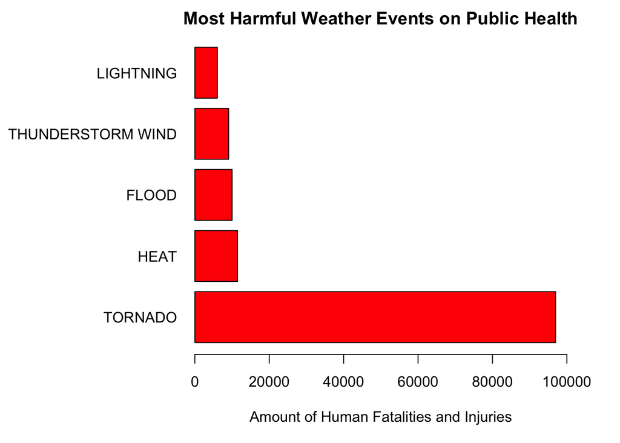

```r
# Removes any scientific notation from the chart
options(scipen=5)
# Adjusts the margins for the chart
par(mar=c(5,11,2,3))
barplot(storm.health.total$PUBLIC.HEALTH,
        names.arg = head(storm.health.total$EVTYPE),
        horiz = TRUE,
        col = "red",
        las = 1,
        xlim = c(0,100000),
        xlab = "Amount of Human Fatalities and Injuries",
        main = "Most Harmful Weather Events on Public Health")
```

With regards to economic impacts, the most disasterous weather events were related to flooding, ice storms/hail, and tornadoes. The chart below helps illustrate the level of economic damage of the most impactful weather events:

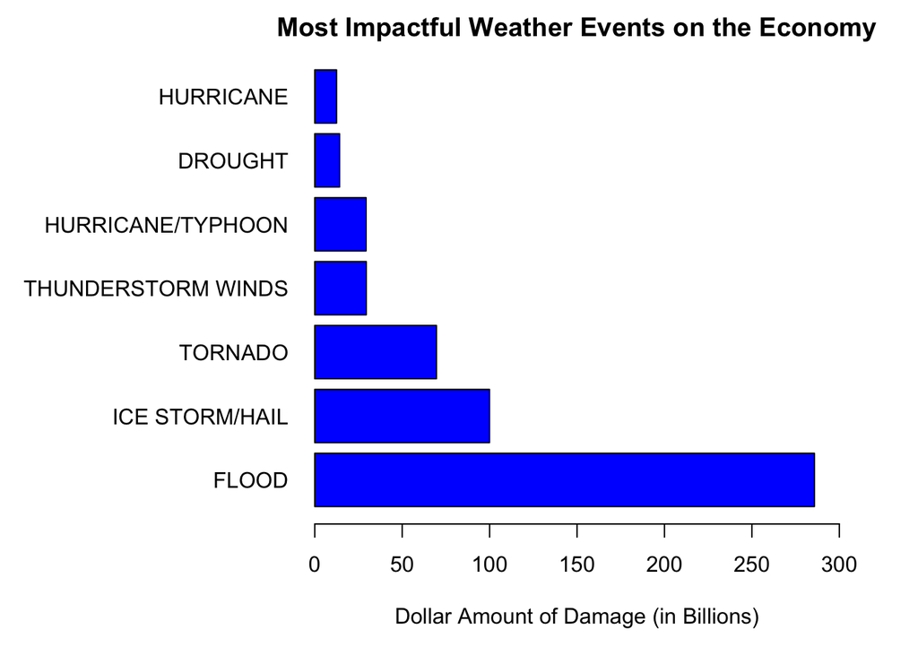

```r
# Adjusts the margins for the chart
par(mar=c(5,12,2,3))
barplot(storm.damages.total$DAMAGES.TOTAL,
        names.arg = storm.damages.total$EVTYPE,
        horiz = TRUE,
        col = "blue",
        las = 1,
        xlim = c(0,300),
        xlab = "Dollar Amount of Damage (in Billions)",
        main = "Most Impactful Weather Events on the Economy")
```